# Week 1 Assignment

Ajay

2025-03-26

# Exercise 1

# This program checks if all elements in a numeric vector are positive numbers

```r
# Create a numeric vector with 4 elements (1, 2, -3, 4)
# I specifically chose these values to test both cases of the if-else statement
x <- c(1, 2, -3, 4)
# My vector containing both positive and negative numbers
# MY IF-ELSE LOGIC:
# I implemented this conditional check to verify if ALL numbers are positive
if(all(x > 0)) {
  # Using all() function to check every element
  print("All Positives")
} else {
  # Case when at least one number fails the positive check
  print("Not all positives")
}
```

```
## [1] "Not all positives"
```

```r
# explaination:
# I created this to practice conditional statements and vector operations in R.
#It demonstrates my understanding ofVector creation,Logical conditions,If-else control flow,The all() function
```

#Exercise 2 # We want to determine which expression is ALWAYS FALSE when # at least one element in logical vector x is TRUE

```r
# Let's create test cases to evaluate each expression
x <- c(TRUE, FALSE, TRUE)
# Our test vector with at least one TRUE

# 1. all(x)
# Checks if ALL elements are TRUE
# Returns TRUE only if every element is TRUE
# In our case: FALSE (because not all are TRUE)
all(x)
```

```
## [1] FALSE
```

```r
# 2. any(x)
# Checks if ANY element is TRUE
# Returns TRUE if at least one element is TRUE
# In our case: TRUE (we have TRUE values)
any(x)
```

```
## [1] TRUE
```

```r
# 3. any(!x)
# Checks if ANY element is FALSE (since ! negates)
# Returns TRUE if at least one element is FALSE
# In our case: TRUE (we have a FALSE value)
any(!x)
```

```
## [1] TRUE
```

```r
# 4. all(!x)
# Checks if ALL elements are FALSE (after negation)
# Returns TRUE only if every original element was FALSE
# In our case: FALSE (because we have TRUE values)
all(!x)
```

```
## [1] FALSE
```

```r
# Conclusion:
# all(!x) is the only expression that is:
# - FALSE when any element is TRUE
# - Only TRUE when all elements are FALSE

# Therefore, the correct answer is all(!x)
```

#Exercise 4 # Calculates the sum of all integers from 1 to n (inclusive)

```r
# code gives output of  sum of integers from 1 to n

sum_n <- function(n) {
# To  check if n is numeric (not character, logical, etc.)
# Verify n is positive (>0)
# Ensure n is an integer (no decimal places)
  if (!is.numeric(n) || n <= 0 || n != as.integer(n)) {
    stop("Input must be a positive integer")
    # Error message for invalid input
  }
# The sum of the first n integers = n*(n + 1)/2
  sum_result <- n * (n + 1) / 2
  # RETURN RESULT
  return(sum_result)
}

#Calculate sum from 1 to 5000
result <- sum_n(5000)
#Function call with n=5000

# FORMATTED OUTPUT
# Using format() with big.mark="," to make large numbers readable
# cat() for clean output without [1] prefix that print() would add
cat("The sum of integers from 1 to 5,000 is:", format(result, big.mark = ","), "\n")
```

```
## The sum of integers from 1 to 5,000 is: 12,502,500
```

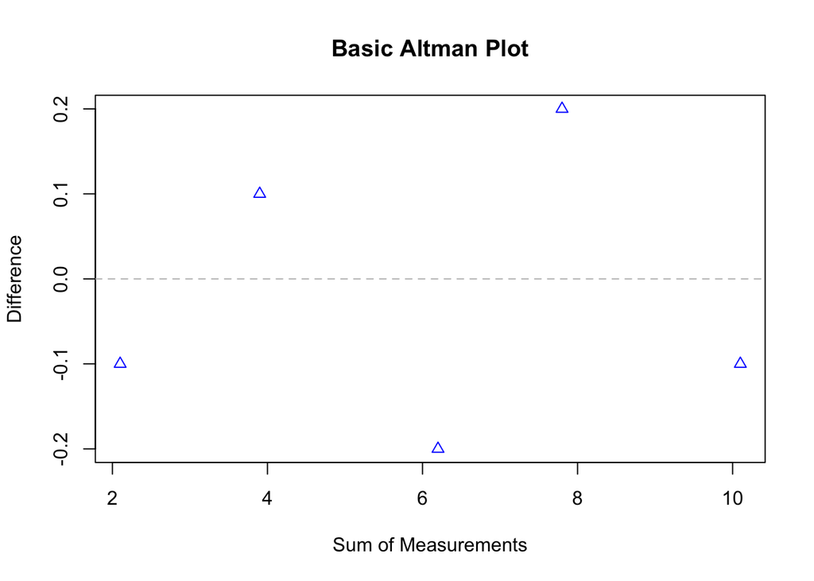

```r
make_altman_plot <- function(x, y) {
  # Basic Altman Plot Function
  # Plots differences (x - y) against sums (x + y)

  # Calculate values
  differences <- x - y
  sums <- x + y

  # Create plot
  plot(sums, differences,
       main = "Basic Altman Plot",
       xlab = "Sum of Measurements",
       ylab = "Difference",
       pch = 24,        # Triangle point shape
       col = "blue")     # Point color

  # Add zero reference line
  abline(h = 0, col = "gray", lty = 2)
}

# Example usage with simple data:
make_altman_plot(c(1,2,3,4,5), c(1.1,1.9,3.2,3.8,5.1))
```

#Exercise 5 # Altman Plot Function #Creates a simple plot to compare two measurement methods by showing their differences versus sums

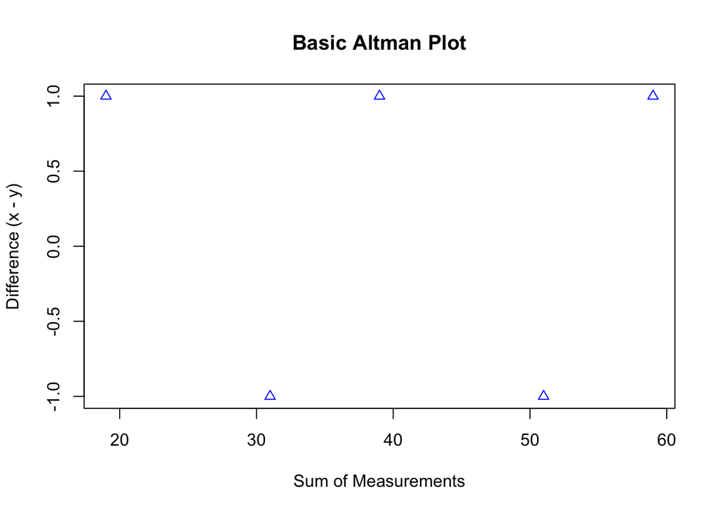

```r
make_altman_plot <- function(x, y) {
# Compute difference between measurements (x - y)
  differences <- x - y
# Compute sum of measurements (x + y)
  sums <- x + y
  plot(sums, differences,
# Plot differences against sums
       main = "Basic Altman Plot",  # Title
       xlab = "Sum of Measurements",  # X-axis label
       ylab = "Difference (x - y)",   # Y-axis label
       # Point styling:
       pch = 24,
# Triangle pointing up (helps spot direction)
       col = "blue"
# Color for visibility
  )
}
# Sample data - measurements from two methods
method_A <- c(10, 15, 20, 25, 30)  # First measurement technique
method_B <- c(9, 16, 19, 26, 29)    # Second measurement technique
# Generate the plot
make_altman_plot(method_A, method_B)
```